# Time Series IV - Revenue Prediction using Neural Nets and Interactive Plots

Jeffrey Wang

2022-12-27

In this project, I predict and plot the revenue of Oregon Campsite using the Neural Net method and R Shiny. This method works well with non-linear pattern relationships between revenue at different time points.

And the steps are shown below,

Step 1: Load and Preprocessing the data and convert to time series format

Step 2: Construct the time series model with the nnetar function and forecast the revenue

Step 3: Visualize and create an interactive plot using R shiny

### Step 1

```r
# Import Data Camping_Revenue as revenue
revenue <- read.csv("/Users/User/Desktop/learning/time series/camping_revenue_97_17.csv", sep = '"', header = F)
```

```r
# Chopping off the useless quotes at 2 positions
library(tidyr)
revenue <- separate(revenue, col = V2,
                    sep = -1,into = c("data", "comma"))
```

```r
#Keep the useful columns only
revenue <- revenue[c("data","V4")]
```

```r
#Conversion to time series
myts <- ts(as.numeric(revenue$V4),
           start = 1997, frequency = 12)
# data is still not clean (outliers and NAs)
summary(myts)
```

```
##    Min. 1st Qu.  Median    Mean 3rd Qu.    Max.    NA's
##       3   18980   23218   36912   26816 3334333       4
```

```r
# all in one cleaning tool
library(forecast)
myts <- tsclean(myts) #outliers and NAs
```

```r
# check the data
summary(myts)
```

```
##    Min. 1st Qu.  Median    Mean 3rd Qu.    Max.
##   14209   19280   23267   23282   26658   34366
```

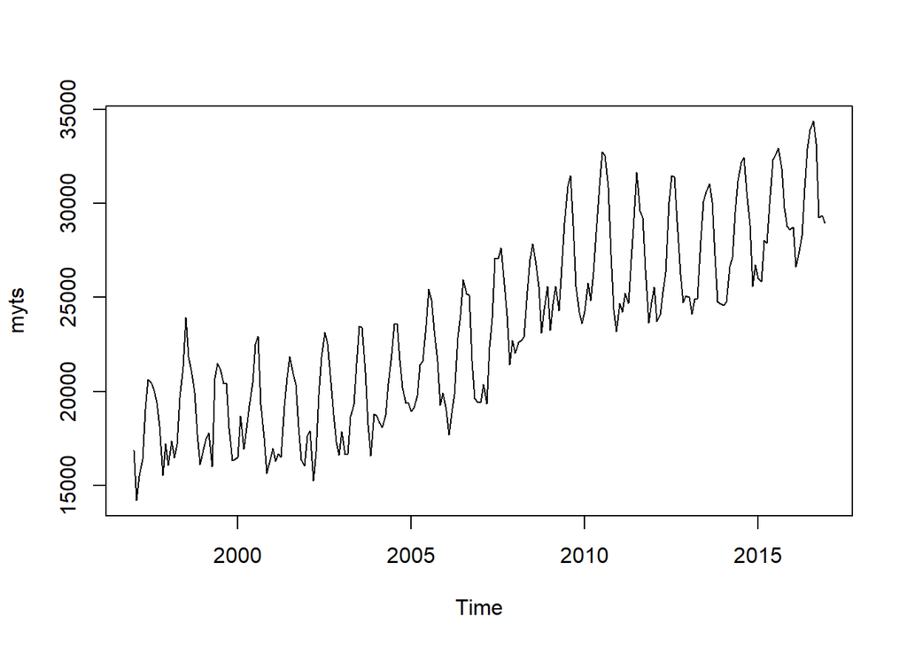

```r
plot(myts)
```

The plot above is the monthly revenue for Oregon Campsite since 1997. As can be seen, the seasonal pattern is clear; summers tend to have higher revenue than winters. In addition, the revenue increases yearly. Both trend and seasonal patterns should be taken into consideration when predicting revenue.

### Step 2

```r
#set up a Neural Network model
mynnetar <- nnetar(myts)
```

```r
mynnetar
```

```
## Series: myts
## Model:  NNAR(3,1,2)[12]
## Call:   nnetar(y = myts)
##
## Average of 20 networks, each of which is
## a 4-2-1 network with 13 weights
## options were - linear output units
##
## sigma^2 estimated as 1123929
```

The model is a Seasonal NNAR(3,1,2) model, a third order auto-corelation model with one seasonal lag term, which is in align with our observation.

```r
#forecasting 3 years' revenue with the model
nnetforecast <- forecast(mynnetar, h = 36,
                         PI = T # prediction interval
                         )
```

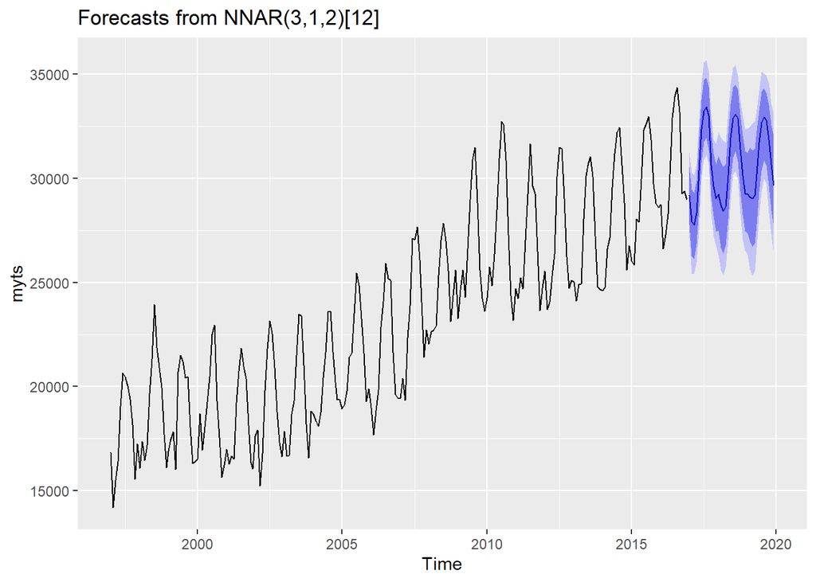

```r
#Visualized the foretasted value
library(ggplot2)
autoplot(nnetforecast)
```

### Step 3

```r
# data we need for the graph
data <- nnetforecast$x
lower <- nnetforecast$lower[,2] # 95% CI
upper <- nnetforecast$upper[,2]
pforecast <- nnetforecast$mean

mydata <- cbind(data, lower, upper,
                pforecast)
```

```r
library(dygraphs)

#Fetch the dataset and create the title
dygraph(mydata, main = "Oregon Campsite Restaurant") %>%
  # the zoom-in tool
  dyRangeSelector() %>%
  #map the time series data
  dySeries(name = "data", label = "Revenue Data") %>%
  #map the predicted data
  dySeries(c("lower","pforecast","upper"), label = "Revenue Forecast") %>%
  #Add the legend
  dyLegend(show = "always", hideOnMouseOut = FALSE) %>%
  #y axis
  dyAxis("y", label = "Monthly Revenue USD") %>%
  #highlight effect
  dyHighlight(highlightCircleSize = 5,
              highlightSeriesOpts = list(strokeWidth = 2)) %>%
  #axis and grid line color
  dyOptions(axisLineColor = "navy", gridLineColor = "grey") %>%
  #annotation: the CF flag on the bottome
  dyAnnotation("2010-8-1", text = "CF", tooltip = "Camp Festival", attachAtBottom = T)
```

[interactive chart not shown]